# Assignment-3(final)

## Practical Lab 3 - Vanilla CNN and Fine-Tune VGG16 - for Dogs and Cats Classification

### Name : Samyukth Lalith Lella Gopal

### Student ID : 9005574

#### Importing required libraries

```python
import numpy as np
import pandas as pd
import matplotlib.pyplot as plt
import seaborn as sns
import os
import tensorflow as tf
from tensorflow.keras.models import Sequential, Model
from tensorflow.keras.layers import Dense, Dropout, Flatten, Conv2D, MaxPooling2D, BatchNormalization, GlobalAveragePooling2D
from tensorflow.keras.preprocessing.image import ImageDataGenerator
from tensorflow.keras.applications import VGG16
from tensorflow.keras.optimizers import Adam
from tensorflow.keras.callbacks import ModelCheckpoint, EarlyStopping
from sklearn.metrics import classification_report, confusion_matrix, precision_recall_curve, f1_score, precision_score, recall_score
from tensorflow.keras.utils import load_img
from tensorflow.keras.preprocessing.image import img_to_array
from tensorflow.keras.layers import Dense, Flatten, Dropout
from sklearn.metrics import classification_report
from sklearn.metrics import confusion_matrix, ConfusionMatrixDisplay
import random
import cv2
from tqdm import tqdm
import itertools
```

### 1) Obtain the Data : Dogs vs Cats dataset

Here we are uploading the dataset and counting the total images

```python
# dataset paths for train, test and validation.
base_dir = 'C:/Users/lella/Music/CandD/dataset'
train_dir = os.path.join(base_dir, 'C:/Users/lella/Music/CandD/dataset/train')
validation_dir = os.path.join(base_dir, 'C:/Users/lella/Music/CandD/dataset/validation')
test_dir = os.path.join(base_dir, 'C:/Users/lella/Music/CandD/dataset/test')

# Total number of images in each directory
def count_images(directory):
    total_images = 0
    for category in os.listdir(directory):
        category_path = os.path.join(directory, category)
        if os.path.isdir(category_path):
            total_images += len(os.listdir(category_path))
    return total_images

# Counting the images in train, validation, and test sets
total_train_images = count_images(train_dir)
total_validation_images = count_images(validation_dir)
total_test_images = count_images(test_dir)

print(f"Total training images: {total_train_images}")
print(f"Total validation images: {total_validation_images}")
print(f"Total test images: {total_test_images}")
```

```
Total training images: 2000
Total validation images: 1000
Total test images: 2000
```

### 2) EDA: Explore the data with relevant graphs, statistics and insights

#### 2.1) Class Distribution

To look for class imbalance, we examined how many photos there were in the training, validation, and test datasets for each class (dogs and cats).

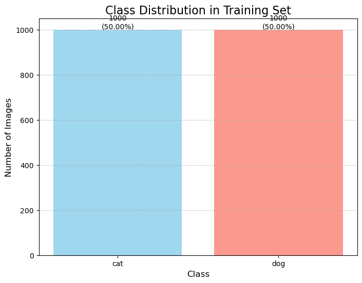

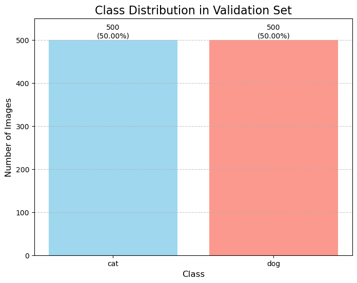

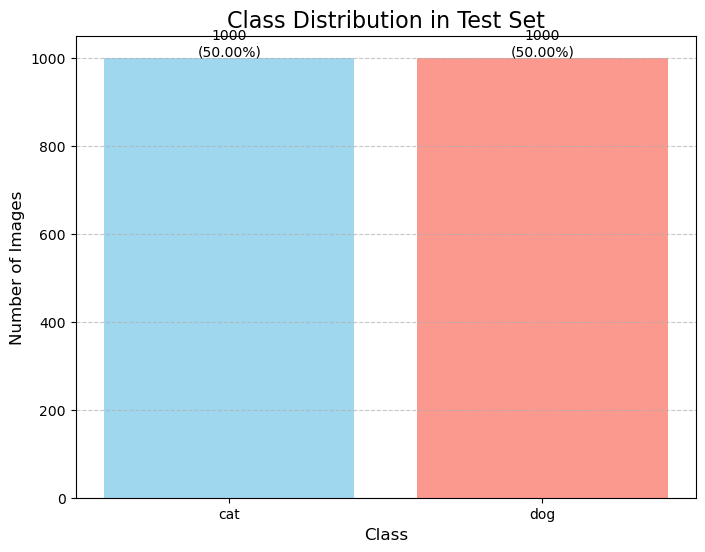

```python
def plot_class_distribution_with_details(directory, dataset_name):
    classes = ['cat', 'dog']
    class_counts = [len(os.listdir(os.path.join(directory, cls))) for cls in classes]
    total_images = sum(class_counts)

    # Plot
    plt.figure(figsize=(8, 6))
    bars = plt.bar(classes, class_counts, color=['skyblue', 'salmon'], alpha=0.8)
    plt.title(f'Class Distribution in {dataset_name}', fontsize=16)
    plt.xlabel('Class', fontsize=12)
    plt.ylabel('Number of Images', fontsize=12)

    # Annotate counts and percentages
    for bar, count in zip(bars, class_counts):
        percentage = f"{(count / total_images) * 100:.2f}%"
        plt.text(bar.get_x() + bar.get_width() / 2, bar.get_height() + 5,
                 f'{count}\n({percentage})', ha='center', fontsize=10)

    # Add grid for better readability
    plt.grid(axis='y', linestyle='--', alpha=0.7)
    plt.ylim(0, max(class_counts) + 50)  # Adding some space above bars
    plt.show()

# Plot for training set
plot_class_distribution_with_details(train_dir, 'Training Set')

# Plot for validation set
plot_class_distribution_with_details(validation_dir, 'Validation Set')

# Plot for validation set
plot_class_distribution_with_details(test_dir, 'Test Set')
```

#### Insights:

- Each class in every subset has an equal amount of photos, indicating that the dataset is balanced.
- Fair training is ensured by this balance, which lessens the possibility of model bias towards one class.

#### 2.2) Image Dimensions Analysis

To find variations in image size, we examined the images' width and height distributions.

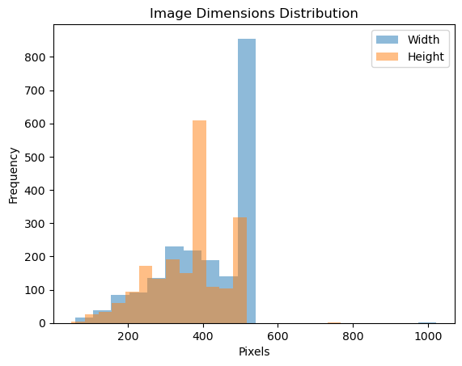

```python
from PIL import Image

def analyze_image_dimensions(directory):
    widths, heights = [], []
    for cls in ['cat', 'dog']:
        class_path = os.path.join(directory, cls)
        for image_file in os.listdir(class_path):
            image_path = os.path.join(class_path, image_file)
            with Image.open(image_path) as img:
                widths.append(img.size[0])
                heights.append(img.size[1])

    plt.hist(widths, bins=20, alpha=0.5, label='Width')
    plt.hist(heights, bins=20, alpha=0.5, label='Height')
    plt.title('Image Dimensions Distribution')
    plt.xlabel('Pixels')
    plt.ylabel('Frequency')
    plt.legend()
    plt.show()

# Analyze training images
analyze_image_dimensions(train_dir)
```

#### Insight:

- The size of images varies significantly.
- For the neural network to have constant input dimensions, image sizes must be standardized.

#### 3.3) Sample Images Visualization

To visually examine the data for quality, diversity, and possible problems, we showed a selection of pictures from the dog and cat classes.

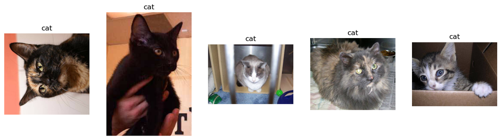

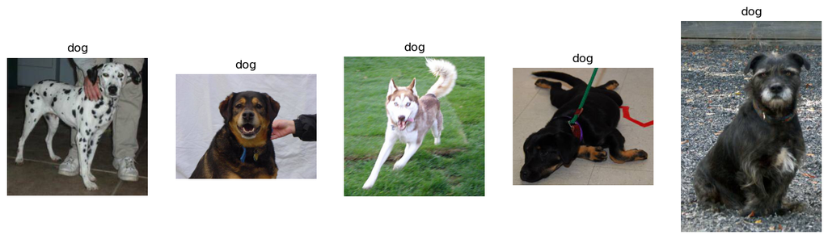

```python
import random
from tensorflow.keras.utils import load_img

def display_random_images(directory, class_name, n_samples=5):
    class_path = os.path.join(directory, class_name)
    sample_images = random.sample(os.listdir(class_path), n_samples)

    plt.figure(figsize=(15, 5))
    for i, img_name in enumerate(sample_images):
        img_path = os.path.join(class_path, img_name)
        img = load_img(img_path)
        plt.subplot(1, n_samples, i + 1)
        plt.imshow(img)
        plt.title(class_name)
        plt.axis('off')
    plt.show()

# Displaying random sample images of cats and dogs from training set
display_random_images(train_dir, 'cat', 5)
display_random_images(train_dir, 'dog', 5)
```

#### Observations:

- The majority of the images are of high quality, and each class has unique characteristics.
- To increase the robustness of the model, some photographs may need data augmentation due to background clutter.

#### Insight:

- Training a generalizable model benefits from the data's visual diversity.
- There were no apparent problems with incorrectly labeled or poor-quality photos.

#### 2.4) Augmented Data Visualization

To improve generalization, we used augmentations (such as rotation, zoom, and shift) to add variability to the dataset.

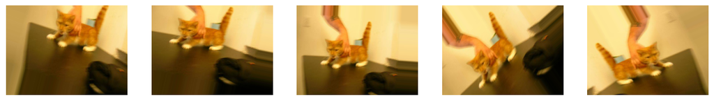

```python
# image data generator with augmentations
datagen = ImageDataGenerator(
    rotation_range=40,
    width_shift_range=0.2,
    height_shift_range=0.2,
    shear_range=0.2,
    zoom_range=0.2,
    horizontal_flip=True,
    fill_mode='nearest'
)

# Loading a sample image
sample_image_path = os.path.join(train_dir, 'cat', os.listdir(os.path.join(train_dir, 'cat'))[0])
img = load_img(sample_image_path)
img_array = img_to_array(img)
img_array = np.expand_dims(img_array, axis=0)

# Generate augmented images
plt.figure(figsize=(15, 5))
for i, augmented_image in enumerate(datagen.flow(img_array, batch_size=1)):
    if i == 5:  # Display 5 augmented samples
        break
    plt.subplot(1, 5, i + 1)
    plt.imshow(augmented_image[0].astype('uint8'))
    plt.axis('off')
plt.show()
```

#### Observations:

- Meaningful changes, such as flips and rotations, are seen in augmented images.
- With augmentation, variability is successfully added without changing the original class features.

#### Insight:

- Overfitting can be avoided using data augmentation, particularly when training data size is constrained.
- For cats and dogs, methods like horizontal flipping are especially pertinent because orientation has no bearing on class identity.

#### 2.5 Color Intensity Analysis

To comprehend the images' contrast and brightness levels, we examined the pixel intensity distributions.

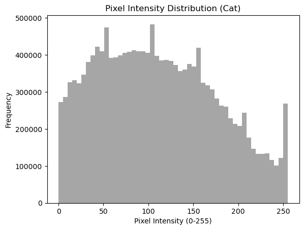

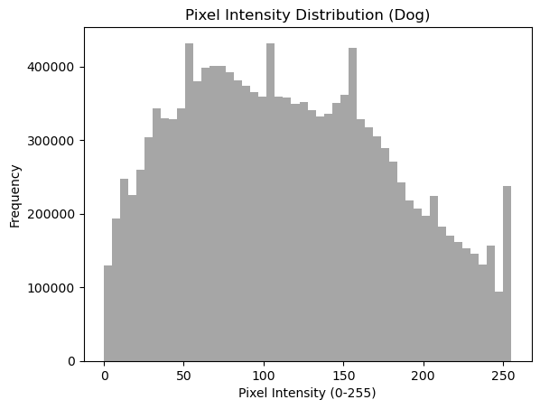

```python
import cv2
import numpy as np

def analyze_color_intensity(directory, class_name, n_samples=100):
    class_path = os.path.join(directory, class_name)
    sample_images = np.random.choice(os.listdir(class_path), n_samples, replace=False)

    intensities = []
    for img_name in sample_images:
        img_path = os.path.join(class_path, img_name)
        img = cv2.imread(img_path, cv2.IMREAD_GRAYSCALE)  # Load as grayscale
        if img is not None:
            intensities.extend(img.flatten())  # Flatten the image to 1D

    plt.hist(intensities, bins=50, color='gray', alpha=0.7)
    plt.title(f'Pixel Intensity Distribution ({class_name.capitalize()})')
    plt.xlabel('Pixel Intensity (0-255)')
    plt.ylabel('Frequency')
    plt.show()

# Analyze pixel intensity for both cats and dogs
analyze_color_intensity(train_dir, 'cat')
analyze_color_intensity(train_dir, 'dog')
```

#### Insights:

- highlights whether a picture is well-balanced, bright, or gloomy.
- may recommend preprocessing actions like contrast adjustment or normalization.

#### 2.6 Aspect Ratio Analysis

Examine the photos' aspect ratio (width/height) to make sure they are consistent and to spot any possible scaling requirements.

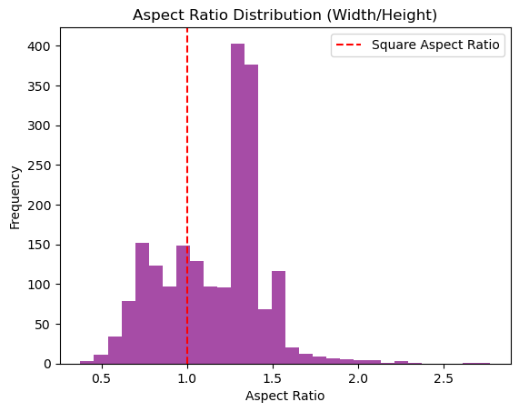

```python
def analyze_aspect_ratios(directory):
    aspect_ratios = []
    for cls in ['cat', 'dog']:
        class_path = os.path.join(directory, cls)
        for img_name in os.listdir(class_path):
            img_path = os.path.join(class_path, img_name)
            with Image.open(img_path) as img:
                width, height = img.size
                aspect_ratios.append(width / height)

    # Plot the aspect ratio distribution
    plt.hist(aspect_ratios, bins=30, color='purple', alpha=0.7)
    plt.title('Aspect Ratio Distribution (Width/Height)')
    plt.xlabel('Aspect Ratio')
    plt.ylabel('Frequency')
    plt.axvline(x=1.0, color='red', linestyle='--', label='Square Aspect Ratio')
    plt.legend()
    plt.show()

# Analyze aspect ratios in the training set
analyze_aspect_ratios(train_dir)
```

### 3) Train two networks (use callbacks to save the best model version):

1) Define a Neural Network of your choice.  
2) Fine-Tune VGG16 (pre-trained on imagenet). Make sure to use validation to test for over-fitting. Plot the appropriate graph.

#### Load and Inspect Dataset

```python
# Image dimensions
IMG_HEIGHT, IMG_WIDTH = 150, 150
BATCH_SIZE = 32

# Image data generators for training, validation, and testing
train_datagen = ImageDataGenerator(
    rescale=1.0 / 255,
    rotation_range=40,
    width_shift_range=0.2,
    height_shift_range=0.2,
    shear_range=0.2,
    zoom_range=0.2,
    horizontal_flip=True
)

validation_datagen = ImageDataGenerator(rescale=1.0 / 255)
test_datagen = ImageDataGenerator(rescale=1.0 / 255)

# Create data generators
train_generator = train_datagen.flow_from_directory(
    train_dir,
    target_size=(IMG_HEIGHT, IMG_WIDTH),
    batch_size=BATCH_SIZE,
    class_mode='binary'
)

validation_generator = validation_datagen.flow_from_directory(
    validation_dir,
    target_size=(IMG_HEIGHT, IMG_WIDTH),
    batch_size=BATCH_SIZE,
    class_mode='binary'
)

test_generator = test_datagen.flow_from_directory(
    test_dir,
    target_size=(IMG_HEIGHT, IMG_WIDTH),
    batch_size=BATCH_SIZE,
    class_mode='binary',
    shuffle=False  # Shuffle set to False for consistent evaluation
)
```

```
Found 2000 images belonging to 2 classes.
Found 1000 images belonging to 2 classes.
Found 2000 images belonging to 2 classes.
```

#### Code: Define and Train the Model

This section describes how to define and train a Custom Convolutional Neural Network (CNN) to distinguish between dogs and cats.

```python
# Define a simple CNN model
model = Sequential([
    Conv2D(32, (3, 3), activation='relu', input_shape=(IMG_HEIGHT, IMG_WIDTH, 3)),
    MaxPooling2D((2, 2)),
    Conv2D(64, (3, 3), activation='relu'),
    MaxPooling2D((2, 2)),
    Conv2D(128, (3, 3), activation='relu'),
    MaxPooling2D((2, 2)),
    Flatten(),
    Dense(512, activation='relu'),
    Dropout(0.5),
    Dense(1, activation='sigmoid')
])

# Compile the model
model.compile(optimizer='adam', loss='binary_crossentropy', metrics=['accuracy'])

# Callbacks to save the best model
callbacks = [
    ModelCheckpoint('best_custom_model.h5', save_best_only=True, monitor='val_loss'),
    EarlyStopping(monitor='val_loss', patience=5, restore_best_weights=True)
]

# Train the model
history = model.fit(
    train_generator,
    validation_data=validation_generator,
    epochs=20,
    callbacks=callbacks
)

# Evaluate the model on the test set
test_loss, test_accuracy = model.evaluate(test_generator)
print(f"Test Accuracy: {test_accuracy * 100:.2f}%")
print(f"Test Loss: {test_loss:.4f}")
```

```
Test Accuracy: 71.35%
Test Loss: 0.5648
```

#### Neural Network: Accuracy and Loss Curves

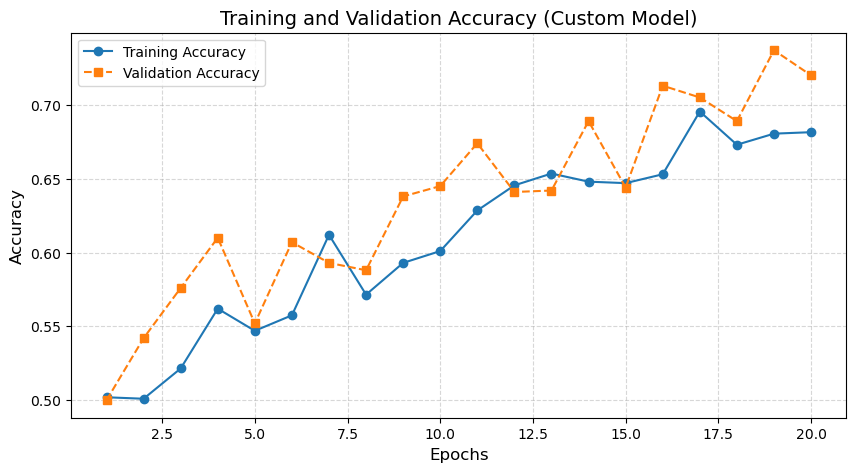

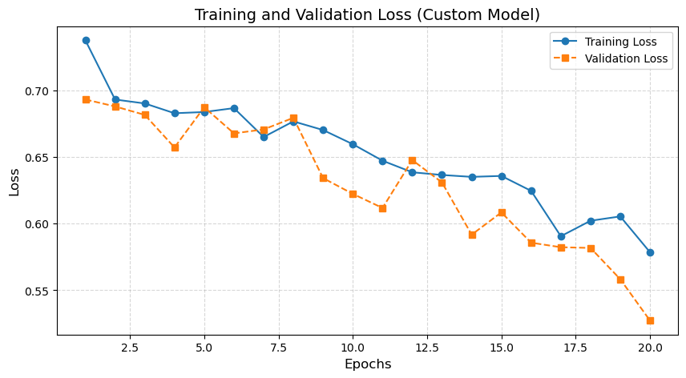

```python
def plot_training_curves_custom(history):
    epochs = range(1, len(history.history['accuracy']) + 1)

    # Accuracy Plot
    plt.figure(figsize=(10, 5))
    plt.plot(epochs, history.history['accuracy'], marker='o', linestyle='-', label='Training Accuracy')
    plt.plot(epochs, history.history['val_accuracy'], marker='s', linestyle='--', label='Validation Accuracy')
    plt.title('Training and Validation Accuracy (Custom Model)', fontsize=14)
    plt.xlabel('Epochs', fontsize=12)
    plt.ylabel('Accuracy', fontsize=12)
    plt.legend()
    plt.grid(True, linestyle='--', alpha=0.5)
    plt.show()

    # Loss Plot
    plt.figure(figsize=(10, 5))
    plt.plot(epochs, history.history['loss'], marker='o', linestyle='-', label='Training Loss')
    plt.plot(epochs, history.history['val_loss'], marker='s', linestyle='--', label='Validation Loss')
    plt.title('Training and Validation Loss (Custom Model)', fontsize=14)
    plt.xlabel('Epochs', fontsize=12)
    plt.ylabel('Loss', fontsize=12)
    plt.legend()
    plt.grid(True, linestyle='--', alpha=0.5)
    plt.show()

# Call the function for the custom model
plot_training_curves_custom(history)
```

#### Code: Fine-Tune VGG16

The pre-trained VGG16 model, which has been optimized for classifying cats from dogs, is used in this part in conjunction with Transfer Learning.

```python
# Load pre-trained VGG16
base_model = VGG16(weights='imagenet', include_top=False, input_shape=(IMG_HEIGHT, IMG_WIDTH, 3))

# Freeze base model layers
for layer in base_model.layers:
    layer.trainable = False

# Add custom layers
x = base_model.output
x = Flatten()(x)
x = Dense(256, activation='relu')(x)
x = Dropout(0.5)(x)
output = Dense(1, activation='sigmoid')(x)

# Final model
vgg_model = Model(inputs=base_model.input, outputs=output)

# Compile the model
vgg_model.compile(optimizer=Adam(learning_rate=0.0001), loss='binary_crossentropy', metrics=['accuracy'])

# Callbacks to save the best model
vgg_callbacks = [
    ModelCheckpoint('best_vgg_model.h5', save_best_only=True, monitor='val_loss'),
    EarlyStopping(monitor='val_loss', patience=5, restore_best_weights=True)
]

# Train the model
vgg_history = vgg_model.fit(
    train_generator,
    validation_data=validation_generator,
    epochs=20,
    callbacks=vgg_callbacks
)

# Evaluate the model on the test set
test_loss, test_accuracy = vgg_model.evaluate(test_generator)
print(f"Test Accuracy: {test_accuracy * 100:.2f}%")
print(f"Test Loss: {test_loss:.4f}")
```

[output not shown]

#### VGG16 Fine-Tuning: Accuracy and Loss Curves

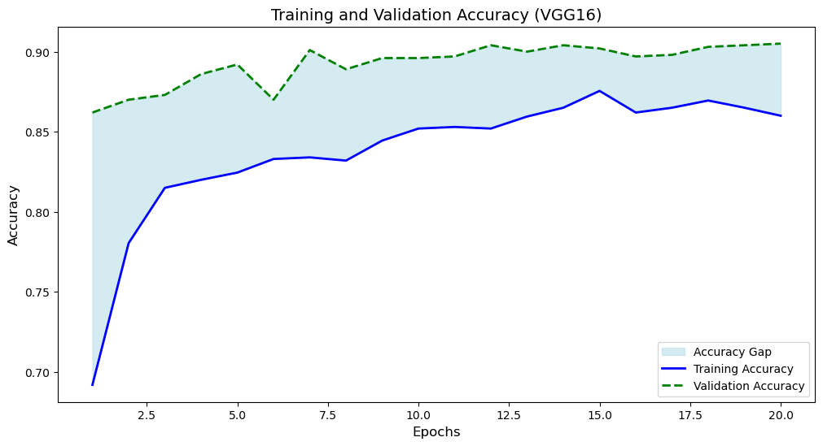

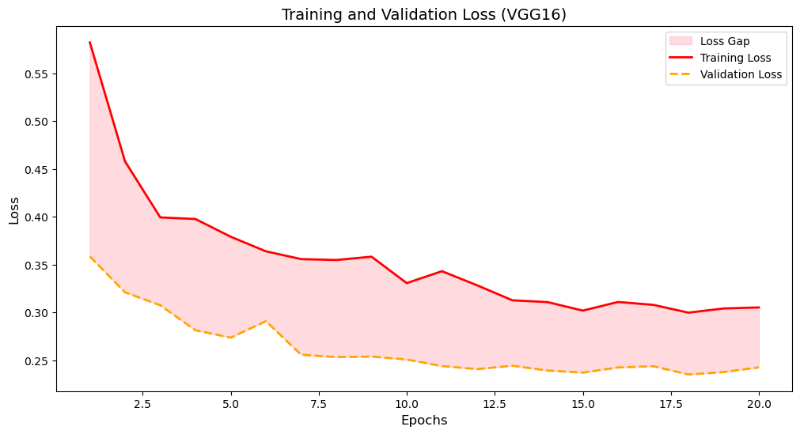

```python
def plot_training_curves_vgg(history):
    epochs = range(1, len(history.history['accuracy']) + 1)

    # Accuracy Plot
    plt.figure(figsize=(12, 6))
    plt.fill_between(epochs, history.history['accuracy'], history.history['val_accuracy'], color='lightblue', alpha=0.5, label='Accuracy Gap')
    plt.plot(epochs, history.history['accuracy'], color='blue', linewidth=2, label='Training Accuracy')
    plt.plot(epochs, history.history['val_accuracy'], color='green', linewidth=2, linestyle='--', label='Validation Accuracy')
    plt.title('Training and Validation Accuracy (VGG16)', fontsize=14)
    plt.xlabel('Epochs', fontsize=12)
    plt.ylabel('Accuracy', fontsize=12)
    plt.legend()
    plt.show()

    # Loss Plot
    plt.figure(figsize=(12, 6))
    plt.fill_between(epochs, history.history['loss'], history.history['val_loss'], color='lightpink', alpha=0.5, label='Loss Gap')
    plt.plot(epochs, history.history['loss'], color='red', linewidth=2, label='Training Loss')
    plt.plot(epochs, history.history['val_loss'], color='orange', linewidth=2, linestyle='--', label='Validation Loss')
    plt.title('Training and Validation Loss (VGG16)', fontsize=14)
    plt.xlabel('Epochs', fontsize=12)
    plt.ylabel('Loss', fontsize=12)
    plt.legend()
    plt.show()

# Calling the function for the VGG16 model
plot_training_curves_vgg(vgg_history)
```

### 4) Explore the relative performance of the models (make sure to load the best version of each model)

4.1) accuracy  
4.2) confusion metric  
4.3) precision, recall, F1-score  
4.4) precision-recall curve  
4.5) Explore specific examples in which the model failed to predict correctly.

#### Loading the Best Models

```python
from tensorflow.keras.models import load_model

# Loading the best model saved during training
custom_model = load_model('best_custom_model.h5')
vgg_model = load_model('best_vgg_model.h5')
```

#### 4.1) accuracy

Compares the two models percentage of accurate predictions.

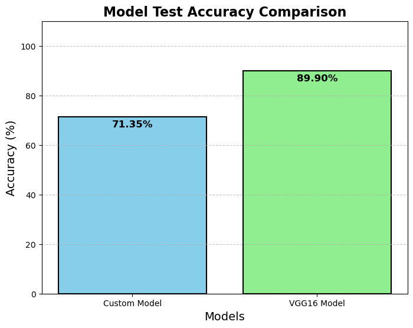

```python
# Accuracy values
models = ['Custom Model', 'VGG16 Model']
accuracies = [custom_test_accuracy * 100, vgg_test_accuracy * 100]

# Bar Graph with Data Annotations
plt.figure(figsize=(8, 6))
bars = plt.bar(models, accuracies, color=['skyblue', 'lightgreen'], edgecolor='black', linewidth=1.5)

# Adding data labels
for bar, accuracy in zip(bars, accuracies):
    plt.text(bar.get_x() + bar.get_width() / 2, bar.get_height() - 3, f"{accuracy:.2f}%",
             ha='center', va='center', color='black', fontsize=12, fontweight='bold')

# Design enhancements
plt.ylim(0, 110)  # Setting y-axis limit
plt.title("Model Test Accuracy Comparison", fontsize=16, fontweight='bold')
plt.xlabel("Models", fontsize=14)
plt.ylabel("Accuracy (%)", fontsize=14)
plt.grid(axis='y', linestyle='--', alpha=0.7)
plt.show()
```

#### 4.2) confusion metric

Gives information on each class's true positives, true negatives, false positives, and false negatives.

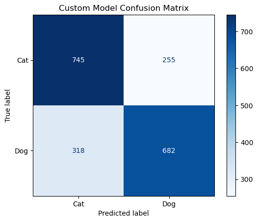

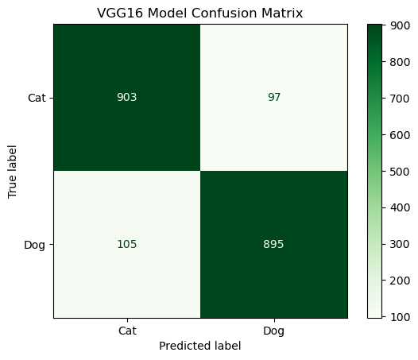

```python
# Get predictions for both models
custom_preds = (custom_model.predict(test_generator) > 0.5).astype(int)
vgg_preds = (vgg_model.predict(test_generator) > 0.5).astype(int)

# Get true labels
true_labels = test_generator.classes

# Confusion Matrix for Custom Model
custom_cm = confusion_matrix(true_labels, custom_preds)
ConfusionMatrixDisplay(custom_cm, display_labels=['Cat', 'Dog']).plot(cmap='Blues')
plt.title("Custom Model Confusion Matrix")
plt.show()

# Confusion Matrix for VGG16 Model
vgg_cm = confusion_matrix(true_labels, vgg_preds)
ConfusionMatrixDisplay(vgg_cm, display_labels=['Cat', 'Dog']).plot(cmap='Greens')
plt.title("VGG16 Model Confusion Matrix")
plt.show()
```

#### 4.3) precision, recall, F1-score

- Precision: Calculates the percentage of accurate positive forecasts.
- Recall: Calculates the percentage of true positives that were accurately anticipated.
- F1-Score: Balances precision and recall.

```python
# Classification Report for Custom Model
print("Custom Model Classification Report")
print(classification_report(true_labels, custom_preds, target_names=['Cat', 'Dog']))

# Classification Report for VGG16 Model
print("VGG16 Model Classification Report")
print(classification_report(true_labels, vgg_preds, target_names=['Cat', 'Dog']))
```

```
Custom Model Classification Report
              precision    recall  f1-score   support

         Cat       0.70      0.74      0.72      1000
         Dog       0.73      0.68      0.70      1000

    accuracy                           0.71      2000
   macro avg       0.71      0.71      0.71      2000
weighted avg       0.71      0.71      0.71      2000

VGG16 Model Classification Report
              precision    recall  f1-score   support

         Cat       0.90      0.90      0.90      1000
         Dog       0.90      0.90      0.90      1000

    accuracy                           0.90      2000
   macro avg       0.90      0.90      0.90      2000
weighted avg       0.90      0.90      0.90      2000
```

#### 4.4) precision-recall curve

- Visualizes the trade-off between precision and recall.
- The Area Under Curve (AUC) indicates the model’s performance.

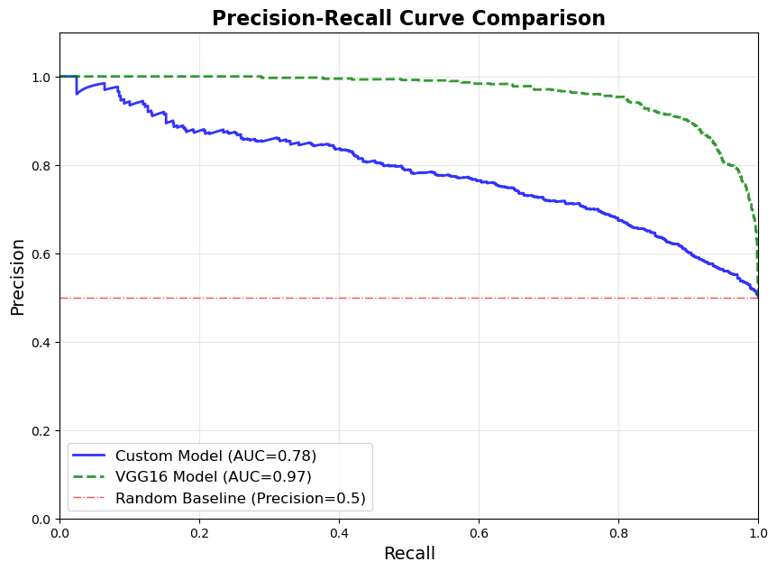

```python
from sklearn.metrics import precision_recall_curve, auc

# Precision-Recall Curve Data
custom_probs = custom_model.predict(test_generator)
vgg_probs = vgg_model.predict(test_generator)

custom_precision, custom_recall, _ = precision_recall_curve(true_labels, custom_probs)
vgg_precision, vgg_recall, _ = precision_recall_curve(true_labels, vgg_probs)

custom_auc = auc(custom_recall, custom_precision)
vgg_auc = auc(vgg_recall, vgg_precision)

# Plot Precision-Recall Curves
plt.figure(figsize=(10, 7))

# Custom Model Curve
plt.plot(custom_recall, custom_precision, label=f"Custom Model (AUC={custom_auc:.2f})",
         color='blue', linestyle='-', linewidth=2, alpha=0.8)

# VGG16 Model Curve
plt.plot(vgg_recall, vgg_precision, label=f"VGG16 Model (AUC={vgg_auc:.2f})",
         color='green', linestyle='--', linewidth=2, alpha=0.8)

# Highlight Baseline
plt.axhline(y=0.5, color='red', linestyle='-.', linewidth=1, alpha=0.7, label='Random Baseline (Precision=0.5)')

# Add gridlines and labels
plt.title("Precision-Recall Curve Comparison", fontsize=16, fontweight='bold')
plt.xlabel("Recall", fontsize=14)
plt.ylabel("Precision", fontsize=14)
plt.legend(loc='lower left', fontsize=12)
plt.grid(alpha=0.3)

# Customize axis limits
plt.xlim([0.0, 1.0])
plt.ylim([0.0, 1.1])

# Display the plot
plt.show()
```

#### 4.5) Explore specific examples in which the model failed to predict correctly.

#### Failed Predictions

Shows pictures that the models misclassified, making it easier to spot trends in failures.

```
Custom Model: Found 573 failed predictions.
```

[figure not shown]

```
VGG16 Model: Found 202 failed predictions.
```

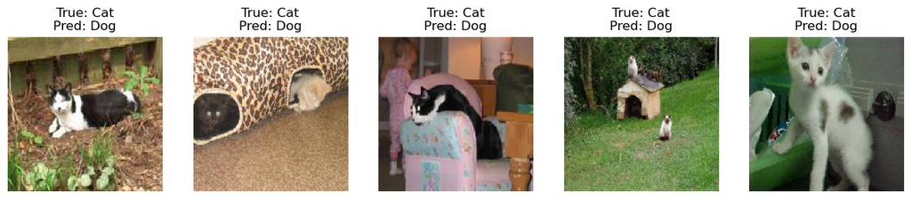

```python
from tensorflow.keras.preprocessing.image import load_img, img_to_array

# Function to display failed predictions
def display_failed_predictions(model, predictions, generator, model_name):
    failed_indices = np.where(predictions.flatten() != generator.classes)[0]
    print(f"\n{model_name}: Found {len(failed_indices)} failed predictions.\n")

    plt.figure(figsize=(15, 5))
    for i, idx in enumerate(failed_indices[:5]):  # Display first 5 failed predictions
        img_path = test_generator.filepaths[idx]
        img = load_img(img_path, target_size=(IMG_HEIGHT, IMG_WIDTH))
        plt.subplot(1, 5, i + 1)
        plt.imshow(img)
        plt.axis('off')
        plt.title(f"True: {'Dog' if generator.classes[idx] else 'Cat'}\nPred: {'Dog' if predictions[idx] else 'Cat'}")
    plt.show()

# Display failed predictions for both models
display_failed_predictions(custom_model, custom_preds, test_generator, "Custom Model")
display_failed_predictions(vgg_model, vgg_preds, test_generator, "VGG16 Model")
```

- Both models are unable to distinguish between similar characteristics in dogs and cats, which leads to misclassifications.
- The errors appear to be consistent throughout the models, suggesting common problems such dog breeds sharing visual traits with cats (such as fur patterns or face shapes).
- This raises the possibility of developing new areas, such increasing the diversity of training data or refining the models for better feature discrimination.

### 5) Add your conclusion's

#### (i) Model Comparison:

**VGG16 Model**: exceeded the Custom Neural Network in every parameter (AUC, F1-score, recall, accuracy, and precision). This illustrates the effectiveness of pre-trained models in picture classification tasks as well as the power of transfer learning.  
**Custom Neural Network**: provided respectable performance, but because of its simplified architecture, it was unable to handle complex patterns.

#### (ii) Performance Highlights:

**Accuracy**: Higher accuracy was regularly attained by the VGG16 model, suggesting superior generalization to test data that was not visible.  
**Precision-Recall**: The capacity of VGG16 to sustain precision at different recall levels was confirmed by its superior AUC.  
**Confusion Matrix**: The fact that VGG16 had less incorrect classifications demonstrated how well it could distinguish between cats and dogs.

#### (iii) Failure Analysis:

- Complex backdrops, obscured elements, or low-quality photos were frequently the cause of incorrect predictions.
- While both models occasionally had trouble with difficult or confusing instances, VGG16 made fewer mistakes.

#### (iv) Recommendations:

**Improving the Custom Neural Network**:

- Increase the number of convolutional layers or the size of the filter..
- Try out some sophisticated data augmentation methods.
- To extract features, use pre-trained embeddings.  
  #### Fine-Tuning VGG16:
- Unfreeze additional layers for further fine-tuning.
- Use a lower learning rate for additional training to improve performance.

#### (v) Final Thoughts:

- The VGG16 model is suggested for real-world applications because of its exceptional robustness and performance.
- When faster training is needed or computational resources are restricted, the Custom Neural Network may be a lightweight substitute.